# Coursera - Practical Machine Learning

Dominik Koch

Sunday, June 21, 2015

### Story

Using devices such as Jawbone Up, Nike FuelBand, and Fitbit it is now possible to collect a large amount of data about personal activity relatively inexpensively. These type of devices are part of the quantified self movement - a group of enthusiasts who take measurements about themselves regularly to improve their health, to find patterns in their behavior, or because they are tech geeks. One thing that people regularly do is quantify how much of a particular activity they do, but they rarely quantify how well they do it. In this project, your goal will be to use data from accelerometers on the belt, forearm, arm, and dumbell of 6 participants. They were asked to perform barbell lifts correctly and incorrectly in 5 different ways. More information is available from the website here: http://groupware.les.inf.puc-rio.br/har (see the section on the Weight Lifting Exercise Dataset).

### Data

The training data for this project are available here:

https://d396qusza40orc.cloudfront.net/predmachlearn/pml-training.csv

The test data are available here:

https://d396qusza40orc.cloudfront.net/predmachlearn/pml-testing.csv

The data for this project come from this source: http://groupware.les.inf.puc-rio.br/har. If you use the document you create for this class for any purpose please cite them as they have been very generous in allowing their data to be used for this kind of assignment.

### Task

The goal of your project is to predict the manner in which they did the exercise. This is the “classe” variable in the training set. You may use any of the other variables to predict with. You should create a report describing how you built your model, how you used cross validation, what you think the expected out of sample error is, and why you made the choices you did. You will also use your prediction model to predict 20 different test cases.

1. Your submission should consist of a link to a Github repo with your R markdown and compiled HTML file describing your analysis. Please constrain the text of the writeup to < 2000 words and the number of figures to be less than 5. It will make it easier for the graders if you submit a repo with a gh-pages branch so the HTML page can be viewed online (and you always want to make it easy on graders :-).
2. You should also apply your machine learning algorithm to the 20 test cases available in the test data above. Please submit your predictions in appropriate format to the programming assignment for automated grading. See the programming assignment for additional details.

Due to security concerns with the exchange of R code, your code will not be run during the evaluation by your classmates. Please be sure that if they download the repo, they will be able to view the compiled HTML version of your analysis.

### General preparation

At the beginning of the code all required R Packages are loaded. The working directory is needed for creating the data folder. And the seed is set for reproducibility.

```r
# Import packages
library(knitr)
library(caret)

# Working directory
wd <- getwd()

# Reproducibility
set.seed(42)
```

### Download data

Download the csv files in the data folder. If there is no *data* folder yet, it will be created. The data will only be downloaded once.

```r
# Create folder
if(!file.exists(file.path(wd,"data"))){
  dir.create(file.path(wd,"data"))
}

# Download csv files
url <- "https://d396qusza40orc.cloudfront.net/predmachlearn/pml-training.csv"
if(!file.exists(file.path(wd,"data","training.csv"))){
  download.file(url, file.path(wd,"data","training.csv"))
}

url <- "https://d396qusza40orc.cloudfront.net/predmachlearn/pml-testing.csv"
if(!file.exists(file.path(wd,"data","testing.csv"))){
  download.file(url, file.path(wd,"data","testing.csv"))
}

# Check data
list.files(file.path(wd,"data"))
```

```
## [1] "testing.csv"  "training.csv"
```

### Import data

In the next step the csv files will be imported

```r
data.training <- read.table("data\\training.csv", sep=",", header = TRUE)
data.coursera <- read.table("data\\testing.csv",  sep=",", header = TRUE)

dim(data.training)
```

```
## [1] 19622   160
```

```r
dim(data.coursera)
```

```
## [1]  20 160
```

```r
#colnames(data.training)
```

The training data set consists of 19622 observations and 160 variables. The test data set contains only 20 observations and 160 variables. We want to predict the variable called **classe**. In the data.coursera set the outcome was replaced by the variable **problem_id**.

### Clean data

In this section all useless variables will be filtered out. At first some general information like timestamps or simple row numbers because these variables won’t contribute to the classification.

[output not shown]

```r
data.training <- data.training[,-c(1,3,4,5,6,7)]
```

```r
data.training <- data.training[, colSums(is.na(data.training)) == 0]
```

In the next step I only want to drop near zero variance predictors. These predictors only have one unique value or have both of the following characteristics:

- they have very few unique values relative to the number of samples
- the ratio of the frequency of the most common value is large

This is true for:

```r
nzv <- nearZeroVar(data.training, saveMetrics = TRUE)
nzv[nzv$nzv == TRUE, ]
```

```
##                          freqRatio percentUnique zeroVar  nzv
## kurtosis_roll_belt      1921.60000    2.02323922   FALSE TRUE
## kurtosis_picth_belt      600.50000    1.61553358   FALSE TRUE
## kurtosis_yaw_belt         47.33005    0.01019264   FALSE TRUE
## skewness_roll_belt      2135.11111    2.01304658   FALSE TRUE
## skewness_roll_belt.1     600.50000    1.72255631   FALSE TRUE
## skewness_yaw_belt         47.33005    0.01019264   FALSE TRUE
## max_yaw_belt             640.53333    0.34654979   FALSE TRUE
## min_yaw_belt             640.53333    0.34654979   FALSE TRUE
## amplitude_yaw_belt        50.04167    0.02038528   FALSE TRUE
## kurtosis_roll_arm        246.35897    1.68178575   FALSE TRUE
## kurtosis_picth_arm       240.20000    1.67159311   FALSE TRUE
## kurtosis_yaw_arm        1746.90909    2.01304658   FALSE TRUE
## skewness_roll_arm        249.55844    1.68688207   FALSE TRUE
## skewness_pitch_arm       240.20000    1.67159311   FALSE TRUE
## skewness_yaw_arm        1746.90909    2.01304658   FALSE TRUE
## kurtosis_roll_dumbbell  3843.20000    2.02833554   FALSE TRUE
## kurtosis_picth_dumbbell 9608.00000    2.04362450   FALSE TRUE
## kurtosis_yaw_dumbbell     47.33005    0.01019264   FALSE TRUE
## skewness_roll_dumbbell  4804.00000    2.04362450   FALSE TRUE
## skewness_pitch_dumbbell 9608.00000    2.04872082   FALSE TRUE
## skewness_yaw_dumbbell     47.33005    0.01019264   FALSE TRUE
## max_yaw_dumbbell         960.80000    0.37203139   FALSE TRUE
## min_yaw_dumbbell         960.80000    0.37203139   FALSE TRUE
## amplitude_yaw_dumbbell    47.92020    0.01528896   FALSE TRUE
## kurtosis_roll_forearm    228.76190    1.64101519   FALSE TRUE
## kurtosis_picth_forearm   226.07059    1.64611151   FALSE TRUE
## kurtosis_yaw_forearm      47.33005    0.01019264   FALSE TRUE
## skewness_roll_forearm    231.51807    1.64611151   FALSE TRUE
## skewness_pitch_forearm   226.07059    1.62572623   FALSE TRUE
## skewness_yaw_forearm      47.33005    0.01019264   FALSE TRUE
## max_yaw_forearm          228.76190    0.22933442   FALSE TRUE
## min_yaw_forearm          228.76190    0.22933442   FALSE TRUE
## amplitude_yaw_forearm     59.67702    0.01528896   FALSE TRUE
```

```r
nzv <- nearZeroVar(data.training)
data.training <- data.training[, -nzv]
```

After dropping near zero variance predictors there are 19622 observations and 54 variables left.

### Split data

Now it is time to split the available data in a training (70%) and a testing (30%) partition. The training set will be used to train the model an the testing set is for validating the model on new data. It is very important to use new data for the validation in order to recieve unbiased performance results.

```r
inTrain <- createDataPartition(y=data.training$classe, p=0.7, list=FALSE)
data.testing <-  data.training[-inTrain,]
data.training <- data.training[inTrain,]
```

### Build Model

```r
fitControl <- trainControl(
  method = "cv",
  number = 5)

fitMod <- train(classe ~ .,
                method = "rf",
                trainControl = fitControl,
                data = data.training,
                ntree = 50)
fitMod
```

```
## Random Forest
##
## 13737 samples
##    53 predictor
##     5 classes: 'A', 'B', 'C', 'D', 'E'
##
## No pre-processing
## Resampling: Bootstrapped (25 reps)
##
## Summary of sample sizes: 13737, 13737, 13737, 13737, 13737, 13737, ...
##
## Resampling results across tuning parameters:
##
##   mtry  Accuracy   Kappa      Accuracy SD  Kappa SD
##    2    0.9853032  0.9814101  0.002121308  0.002695235
##   29    0.9876658  0.9844005  0.001604742  0.002033377
##   57    0.9744107  0.9676347  0.003925062  0.004962912
##
## Accuracy was used to select the optimal model using  the largest value.
## The final value used for the model was mtry = 29.
```

### Evaluate Model

After building the model I want to know its performance. Therefore I use the testing data set I put aside earlier.

```r
evalMod <- predict(fitMod, newdata = data.testing)
confusionMatrix(data.testing$classe, evalMod)
```

```
## Confusion Matrix and Statistics
##
##           Reference
## Prediction    A    B    C    D    E
##          A 1671    3    0    0    0
##          B    8 1129    2    0    0
##          C    0   10 1012    4    0
##          D    0    2   12  950    0
##          E    0    0    1    2 1079
##
## Overall Statistics
##
##                Accuracy : 0.9925
##                  95% CI : (0.99, 0.9946)
##     No Information Rate : 0.2853
##     P-Value [Acc > NIR] : < 2.2e-16
##
##                   Kappa : 0.9905
##  Mcnemar's Test P-Value : NA
##
## Statistics by Class:
##
##                      Class: A Class: B Class: C Class: D Class: E
## Sensitivity            0.9952   0.9869   0.9854   0.9937   1.0000
## Specificity            0.9993   0.9979   0.9971   0.9972   0.9994
## Pos Pred Value         0.9982   0.9912   0.9864   0.9855   0.9972
## Neg Pred Value         0.9981   0.9968   0.9969   0.9988   1.0000
## Prevalence             0.2853   0.1944   0.1745   0.1624   0.1833
## Detection Rate         0.2839   0.1918   0.1720   0.1614   0.1833
## Detection Prevalence   0.2845   0.1935   0.1743   0.1638   0.1839
## Balanced Accuracy      0.9973   0.9924   0.9913   0.9954   0.9997
```

The confusion Matrix seems pretty good. Only few observations were predicted into the wrong class. Also the accuracy with 0.9925234 is pretty high.

```r
accuracy <- postResample(evalMod, data.testing$classe)
accuracy
```

```
##  Accuracy     Kappa
## 0.9925234 0.9905416
```

The expected out of sample error is calculated via 1 minus the accuracy.

```r
eoo.sampleerror <- 1 - as.numeric(accuracy[1])
eoo.sampleerror
```

```
## [1] 0.007476636
```

Last but not least I still have to predict the 20 test cases.

```r
pred.coursera <- predict(fitMod, newdata = data.coursera)
pred.coursera
```

```
##  [1] B A B A A E D B A A B C B A E E A B B B
## Levels: A B C D E
```

And write my predictions to txt-files.

```r
if(!file.exists(file.path(wd,"submission"))){
  dir.create(file.path(wd,"submission"))
}

pml_write_files = function(x){
  n = length(x)
  for(i in 1:n){
    filename = paste0("submission\\problem_id_",i,".txt")
    write.table(x[i],file=filename,quote=FALSE,row.names=FALSE,col.names=FALSE)
  }
}

pml_write_files(pred.coursera)
```

### Variable Importance

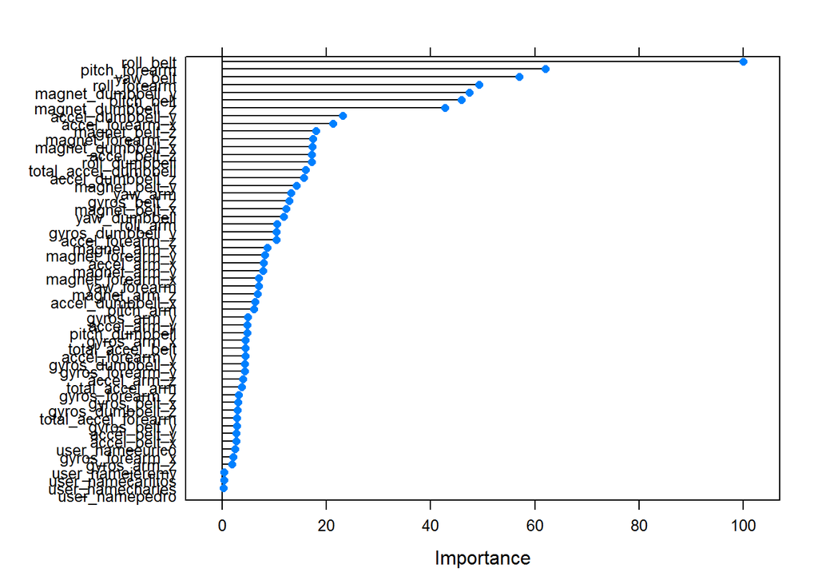

```r
plot(varImp(fitMod))
```

### Selected Predictors vs Accuracy

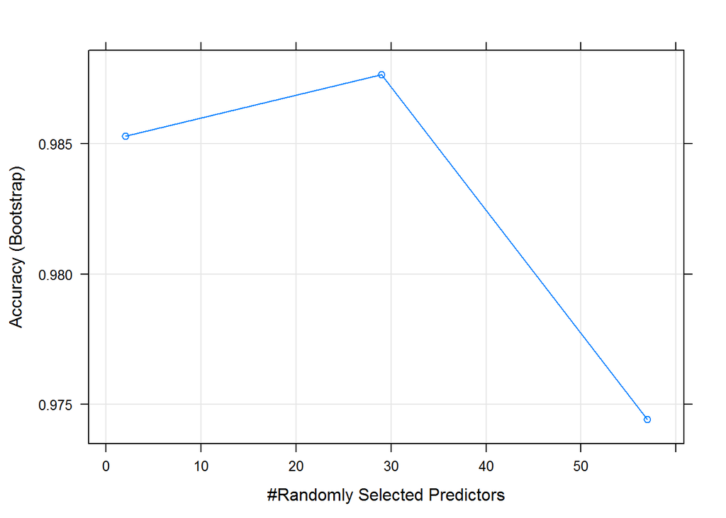

```r
plot.train(fitMod)
```